# maraton

## 🚀 Cel projektu

Użytkownik:

- wprowadza swoje dane
- model AI zmienia je do postaci danych przekazywanych do modelu ML
- może porównać swój czas docelowy z przewidywanym
- otrzymuje przewidywany czas półmaratonu
- otrzymuje feedback oparty na danych

## 🧰 Technologie i narzędzia

| Kategoria | Technologia | Zastosowanie |
| --- | --- | --- |
| ML / predykcja | `pycaret.regression` | Tworzenie i trenowanie modelu regresji |
| Interfejs | `streamlit` | UI do wprowadzania danych i prezentacji wyników |
| Walidacja | `pandera`, | Sprawdzanie poprawności danych wejściowych |
| Przechowywanie | `DigitalOcean Spaces (S3)` | Model i dane do wykresów |
| AI & LLM | `OpenAI GPT-4o`, `instructor` | Generowanie personalizowanego feedbacku |
| Monitoring | `langfuse` | Obserwacja działania modelu AI |
| Wizualizacja | `matplotlib`, `pandas` | Tworzenie wykresów, analiza danych |
| Inne | `joblib`, `boto3`, `dotenv` | Serializacja modelu, integracja z chmurą, środowisko |

## 📅 Proces tworzenia

### 1. 🔢 Dane & analiza:

- Zbiór danych zawierający płeć, wiek, grupa wiekowa, czasy biegów na 5km/10km/15km/20km/cały dystans, tempo na 5km/10km/15km/20km/cały dystans
- Oczyszczenie danych przygotowanie ich do tworzenia modelu, usuwanie danych odstających (outlierów)

### 2. 🤖 Tworzenie modelu:

- Użycie `pycaret` do wyboru najlepszego modelu regresji
- Ewaluacja metryk (MAE, MSE)
- Uzyskano wartość MAE na poziomie 162, co oznacza, że średni błąd predykcji modelu wynosi 162 sekundy (ok. 2,7 minuty).

### 3. 📂 Serializacja:

- Zapis modelu `.pkl` przez moduł pakietu `pycaret.regression: save_model`
- Upload modelu i danych porównawczych do DigitalOcean Spaces

### 4. 🌐 Aplikacja Streamlit:

- UI pozwalający wprowadzać dane
- Integracja z modelem ML
- Wczytywanie danych z chmury
- Wykresy z porównaniem czasu użytkownika do czasu jaki chce osiągnąć

## 📸 Screeny i kod

### 1️⃣. Eksploracja danych, Tworzeniee modelu i upload do chmury (Digital Ocean)

#### 🧪 1. Inicjalizacja środowiska ML i przygotowanie danych

```
setup(
    data=df_to_model,
    session_id=123,
    categorical_features=["sex"],
    target="time"
)
```

##### 🤖 2. Wybór najlepszego modelu spośród kilkunastu algorytmów

```
best_model = compare_models()
```

#### 🔧 3. Strojenie hiperparametrów wybranego modelu

```
best_model = tune_model(best_model)
```

##### 🏁 4. Finalizacja (trenowanie na pełnym zbiorze)

```
best_model = finalize_model(best_model)
```

##### 💾 5. Zapis gotowego modelu do pliku `.pkl`

```
save_model(best_model, "marathon_pipeline")
```

#### ☁️ 6. Upload do chumry DO

```
session=boto3.session.Session()

client=session.client(
    's3',
    region_name=os.environ.get("REGION_NAME"),
    endpoint_url=os.environ.get("ENPOINT_URL_KEY"),
    aws_access_key_id=os.environ.get("AWS_ACCESS_KEY_ID"),
    aws_secret_access_key=os.environ.get("AWS_SECRET_ACCESS_KEY")
)

with open("marathon_pipeline.pkl", "rb") as model_file:
    client.put_object(
        Bucket="maraton.data",
        Key="maraton_model/model.pkl",
        Body=model_file,
        ContentType="application/octet-stream"
    )
```

### 2️⃣ UI: Wprowadzanie danych przez użytkownika

Aplikacja oferuje **dwie ścieżki wprowadzania danych**:

#### 🧠 Opcja 1: Semantyczny opis (naturalny język)

Użytkownik może po prostu opisać siebie:

> "Jestem kobietą, mam 28 lat, biegam 5 km w 27 minut, a 10 km w 58 minut."

Model AI (GPT-4o + Pydantic) przekształca ten opis do struktury JSON:

```
{
  "sex": 0,
  "time_5km": "00:27:00",
  "time_10km": "00:58:00"
}
```

📸 Screen: Wpisywanie semantyczne danych

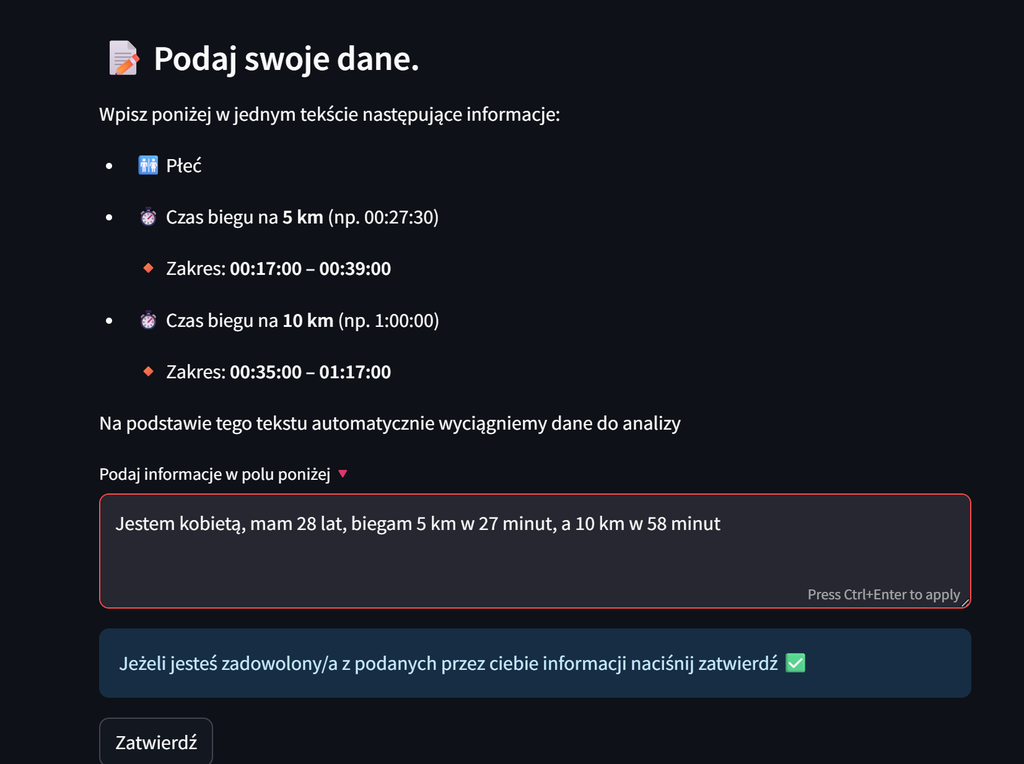

#### 📝 Opcja 2: Klasyczny formularz Streamlit

Użytkownik może też wprowadzić dane ręcznie: 📸 Screen: Formluarz

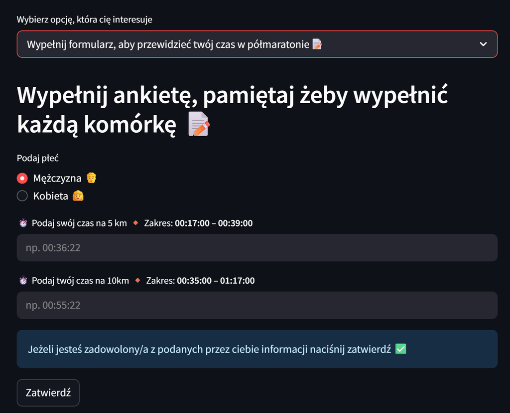

## 🎯 3️⃣ Dodatkowa Funkcjonalność: Ustawienie celu użytkownika (target time)

Użytkownik może wprowadzić czas, który chciałby osiągnąć w półmaratonie, np. 2:30. System porównuje ten czas z prognozowanym przez model.

📸 Screen: UI z wyborem celu

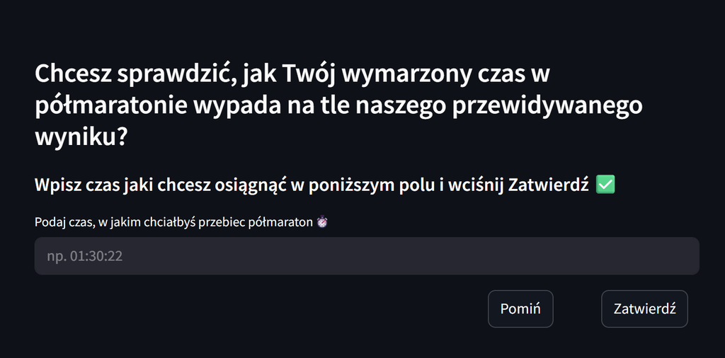

## 📊 4️⃣ Wizualizacja wyników i indywidualny feedback

Po przetworzeniu danych, aplikacja:

- prognozuje czas ukończenia półmaratonu (np. 04:32:15)
- porównuje go z czasem docelowym użytkownika (04:00:00)
- generuje feedback statystyczny na podstawie danych półmaratonu:
  - pokazuje użytkownikowy przewidywany czas w formacie hh:mm:ss oraz słownie np. 1h 20min
  - jaka była różnica między predykcją a rzeczywistym wynikiem w tej grupie
  - zwraca użytkownikowi uwagę na to o ilo powinien poprawić swoje wyniki by osiągnąć zamierzony czas

📸 Screen: UI z feedbackiem

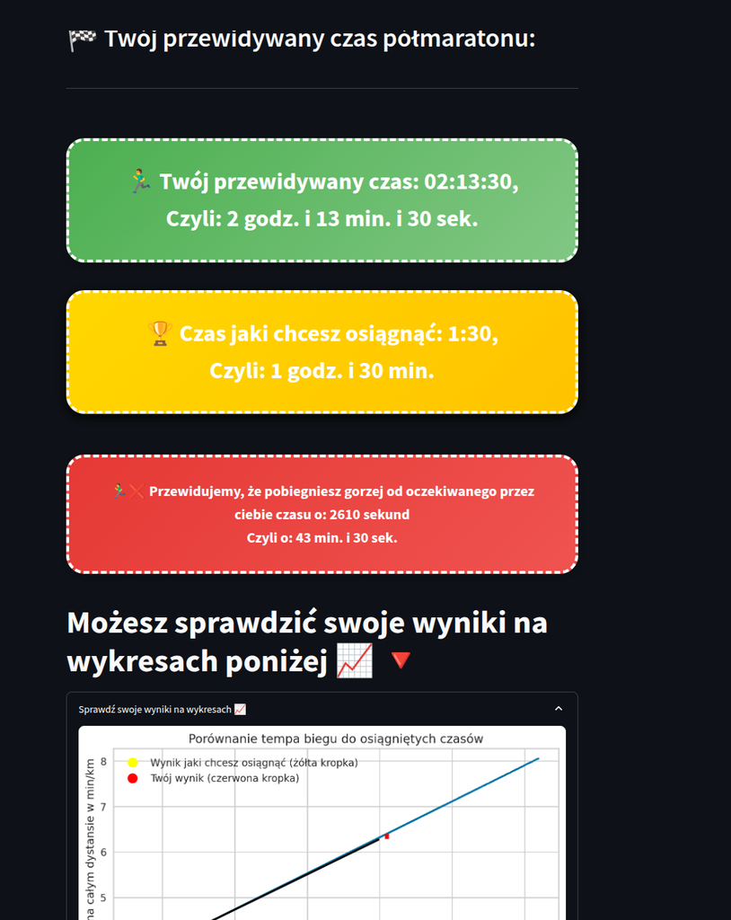